# individual1.Rmd

Tessa Mendoza

11/3/2020

```r
library(tidyverse)
acc <- read.csv("https://raw.githubusercontent.com/xdaiISU/ds202materials/master/hwlabs/fars2017/accident.csv", stringsAsFactors = FALSE)
person <- read.csv("https://raw.githubusercontent.com/xdaiISU/ds202materials/master/hwlabs/fars2017/person.csv", stringsAsFactors = FALSE)
```

**1) Are there some days of the week where more accidents happen than the others?**

Yes - Saturday, Friday, and Sunday are the msot common days of the week for accidents.

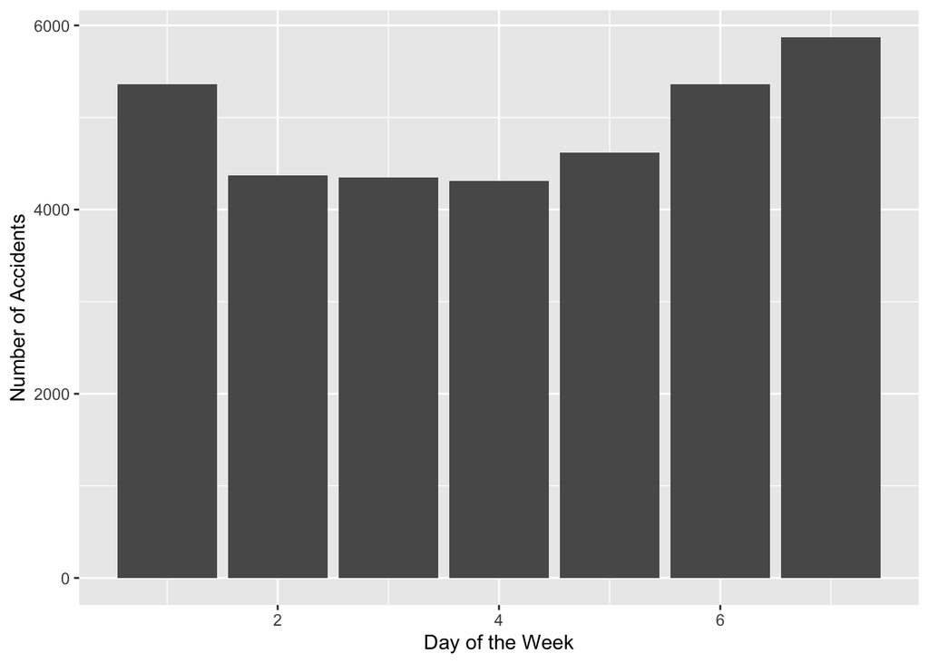

```r
q1 <- acc %>%
  group_by(DAY_WEEK) %>%
  summarise(num = n())

ggplot(q1, aes(x = DAY_WEEK, y = num)) + geom_bar(stat = 'identity') +
  labs(x = "Day of the Week", y = "Number of Accidents")
```

**2) Create a data frame containing the persons who are fatally hurt in the accidents (look up variable INJ_SEV)**

```r
q2 <- person %>%
  filter(INJ_SEV == 4)
head(q2)
```

```
##   STATE ST_CASE VE_FORMS VEH_NO PER_NO STR_VEH COUNTY DAY MONTH HOUR MINUTE
## 1     1   10001        1      1      1       0     73  19     2   23     35
## 2     1   10002        1      1      1       0     89  14     2   14     59
## 3     1   10003        3      2      1       0    101  31     1   20     31
## 4     1   10004        1      1      1       0     73   1     1   16     55
## 5     1   10005        1      1      1       0     13   1     1   20      0
## 6     1   10006        2      1      1       0     49   6     1   18     40
##   RUR_URB FUNC_SYS HARM_EV MAN_COLL SCH_BUS MAKE MAK_MOD BODY_TYP MOD_YEAR
## 1       2        1      38        0       0   20   20421       15     2004
## 2       2        1       1        0       0   37   37402       14     2005
## 3       2        1      12        1       0    2    2404       14     2003
## 4       2        4      30        0       0   30   30046        4     2014
## 5       1        1      35        0       0   12   12471       34     2010
## 6       1        1      34        0       0   49   49032        4     1997
##   TOW_VEH SPEC_USE EMER_USE ROLLOVER IMPACT1 FIRE_EXP AGE SEX PER_TYP INJ_SEV
```

[output cut: 41 more lines]

**3) Create a data frame containing the most dangerous vehicle make in each state. The number of persons fatally hit in the vehicle make is used to assess the (non-)safety of a make. Make sure to handle the missing values appropriately. (look up variable MAKE)**

```r
q3 <- q2 %>%
  filter(!is.na(MAKE)) %>%
  group_by(STATE, MAKE) %>%
  summarize(numFatalities = n()) %>%
  filter(numFatalities == max(numFatalities))
head(q3)
```

```
## # A tibble: 6 x 3
## # Groups:   STATE [6]
##   STATE  MAKE numFatalities
##   <int> <int>         <int>
## 1     1    12           138
## 2     2    12             9
## 3     4    20            88
## 4     5    20            88
## 5     6    49           351
## 6     8    12            63
```

**4) Create a map, and label each state with the most dangerous vehicle. Discuss the definition of the most dangerous vehicle, and what you find from the map.**

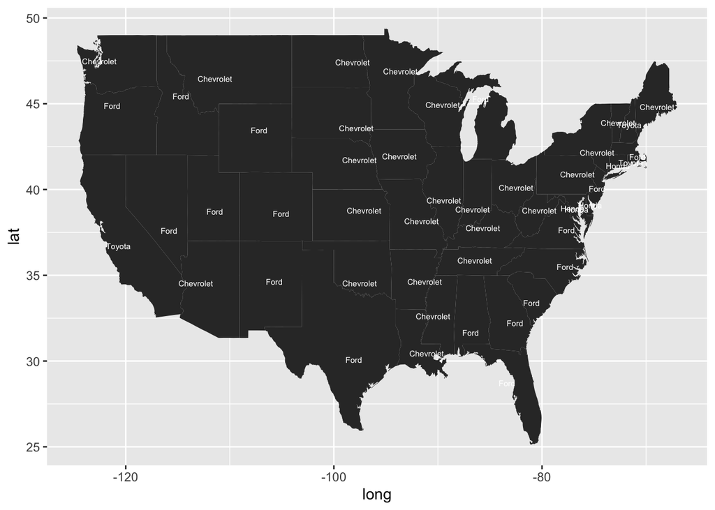

```r
codes <- readxl::read_xlsx("FRPP_GLC_-_United_StatesSep292020.xlsx")
states <- map_data('state')

codes <- codes %>%
  mutate('State Code' = as.numeric(`State Code`))

q3 <- q3 %>%
  inner_join(codes %>% select("State Code", "State Name"), by = c("STATE" = "State Code")) %>%
  distinct()
q3$`State Name` <- tolower(q3$'State Name')

states <- states %>%
  left_join(q3 %>% select("MAKE", "State Name"), by = c("region"= "State Name"))
label <- states %>%
  group_by(region) %>%
  summarise(long = mean(long), lat = mean(lat), make = min(MAKE))
label$make <- factor(label$make, levels = c(12, 20, 49, 37),
                     labels = c("Ford", "Chevrolet", "Toyota", "Honda"))


ggplot(states %>% group_by(region), aes(x=long, y=lat)) +
  geom_polygon(aes(group=group)) +
  geom_text(aes(label = make), size = 2, color = 'white', data = label)
```

In this analysis of the most dangerous vehicle by state, the definition of “dangerous vehicle” was set as the number of fatalities that occurred in each vehicle model. Thus, in Iowa, the largest number of fatalities occurred in Chevrolet vehicles. From the map, it is clear that the majority of the most dangerous vehicles in each state were Ford and Chevrolet cars.

**5) Join the accident and person table (work out which variable(s) to use)**

```r
q5 <- person %>%
  left_join(acc)
```

The above code joins by the following columns: “STATE”, “ST_CASE”, “VE_FORMS”, “COUNTY”, “DAY”, “MONTH”, “HOUR”, “MINUTE”, “RUR_URB”, “FUNC_SYS”, “HARM_EV”, “MAN_COLL”, “SCH_BUS” to avoid duplication of columns.

**6) Tally the number of accidents by day of the week (DAY_WEEK), hour of the day (HOUR) and gender (SEX). Visualize the results.**

```r
q6 <- q5 %>%
  filter(SEX != 8 & SEX != 9) %>%
  filter(HOUR <= 24) %>%
  group_by(DAY_WEEK, HOUR, SEX) %>%
  summarize(total = n())
```

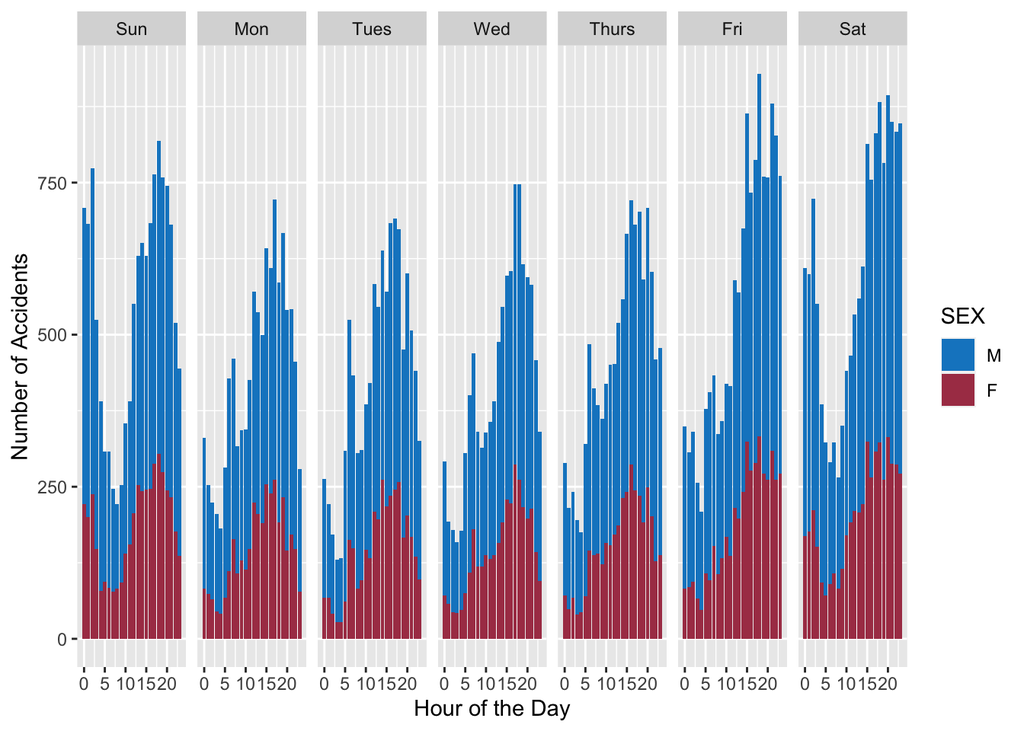

```r
q6$SEX <- factor(q6$SEX, levels = c(1, 2),
                     labels = c("M", "F"))
q6$DAY_WEEK <- factor(q6$DAY_WEEK, labels = c("Sun", "Mon", "Tues", "Wed", "Thurs", "Fri", "Sat"))

ggplot(q6, aes(x = HOUR, y = total, fill = SEX)) + facet_grid(~DAY_WEEK) + geom_bar(stat = 'identity') +
  scale_fill_manual(values=c("#1287C9", "#AB3F54")) +
  labs(x = "Hour of the Day", y = "Number of Accidents")
```

**8) Is summer or winter more dangerous? Does this depend on states? Explore and explain.**

```r
winter <- acc %>%
  filter(between(MONTH, 1, 3) | MONTH == 12)

nrow(winter)
```

```
## [1] 10419
```

```r
meanWinter <- nrow(winter) / 4
meanWinter
```

```
## [1] 2604.75
```

```r
summer <- acc %>%
  filter(between(MONTH, 6, 9))

nrow(summer)
```

```
## [1] 12273
```

```r
meanSummer <- nrow(summer) / 4
meanSummer
```

```
## [1] 3068.25
```

```r
summerByState <- summer %>%
  group_by(STATE) %>%
  summarize(summerCount = n())
summerByState
```

```
## # A tibble: 51 x 2
##    STATE summerCount
##    <int>       <int>
##  1     1         294
##  2     2          29
##  3     4         310
##  4     5         166
##  5     6        1147
##  6     8         243
##  7     9          92
##  8    10          47
##  9    11          11
## 10    12         891
## # … with 41 more rows
```

```r
winterByState <- winter %>%
  group_by(STATE) %>%
  summarize(winterCount = n())
summerByState
```

```
## # A tibble: 51 x 2
##    STATE summerCount
##    <int>       <int>
##  1     1         294
##  2     2          29
##  3     4         310
##  4     5         166
##  5     6        1147
##  6     8         243
##  7     9          92
##  8    10          47
##  9    11          11
## 10    12         891
## # … with 41 more rows
```

```r
byState <- summerByState %>%
  inner_join(winterByState, by = ("STATE" = "STATE"))
byState
```

```
## # A tibble: 51 x 3
##    STATE summerCount winterCount
##    <int>       <int>       <int>
##  1     1         294         270
##  2     2          29          23
##  3     4         310         293
##  4     5         166         137
##  5     6        1147        1058
##  6     8         243         158
##  7     9          92          76
##  8    10          47          32
##  9    11          11           8
## 10    12         891        1050
## # … with 41 more rows
```

```r
state <- codes %>%
  select(`State Name`, `State Code`) %>%
  inner_join(byState, by = c('State Code' = "STATE"))

state <- unique(state)
state
```

```
## # A tibble: 51 x 4
##    `State Name`         `State Code` summerCount winterCount
##    <chr>                       <dbl>       <int>       <int>
##  1 ALABAMA                         1         294         270
##  2 ALASKA                          2          29          23
##  3 ARIZONA                         4         310         293
##  4 ARKANSAS                        5         166         137
##  5 CALIFORNIA                      6        1147        1058
##  6 COLORADO                        8         243         158
##  7 CONNECTICUT                     9          92          76
##  8 DELAWARE                       10          47          32
##  9 DISTRICT OF COLUMBIA           11          11           8
## 10 FLORIDA                        12         891        1050
## # … with 41 more rows
```

```r
winterState <- state %>%
  filter (winterCount - summerCount > 0)
winterState
```

```
## # A tibble: 4 x 4
##   `State Name`   `State Code` summerCount winterCount
##   <chr>                 <dbl>       <int>       <int>
## 1 FLORIDA                  12         891        1050
## 2 HAWAII                   15          25          36
## 3 LOUISIANA                22         211         230
## 4 SOUTH CAROLINA           45         280         301
```

```r
summerState <- state %>%
   filter (summerCount - winterCount > 0)
summerState
```

```
## # A tibble: 47 x 4
##    `State Name`         `State Code` summerCount winterCount
##    <chr>                       <dbl>       <int>       <int>
##  1 ALABAMA                         1         294         270
##  2 ALASKA                          2          29          23
##  3 ARIZONA                         4         310         293
##  4 ARKANSAS                        5         166         137
##  5 CALIFORNIA                      6        1147        1058
##  6 COLORADO                        8         243         158
##  7 CONNECTICUT                     9          92          76
##  8 DELAWARE                       10          47          32
##  9 DISTRICT OF COLUMBIA           11          11           8
## 10 GEORGIA                        13         484         468
## # … with 37 more rows
```